# Forecast Daily Bike Rental Demand Using Time Series Models

Purnendu kumar sinha

2025-11-27

# 1 Introduction

In this project, we analyze bike rental data from the Capital Bikeshare system in Washington, DC (2011–2012) and build time series models to forecast future **daily** rental demand.

Accurate forecasts can help the bike rental company:

- plan how many bikes to keep available,
- improve station-level fleet management,
- inform pricing and promotions, and
- optimize logistics and reduce costs.

We will load, clean, explore, model, and forecast.

# 2 Libraries

```r
library(tidyverse)
library(lubridate)
library(forecast)
```

# 3 Load Data

Make sure `day.csv` from the Bike Sharing Dataset is in the same folder as this Rmd file.

```r
daily <- read_csv("day.csv")
glimpse(daily)
```

```
## Rows: 731
## Columns: 14
## $ instant    <dbl> 1, 2, 3, 4, 5, 6, 7, 8, 9, 10, 11, 12, 13, 14, 15, 16, 17, …
## $ dteday     <date> 2011-01-01, 2011-01-02, 2011-01-03, 2011-01-04, 2011-01-05…
## $ season     <dbl> 1, 1, 1, 1, 1, 1, 1, 1, 1, 1, 1, 1, 1, 1, 1, 1, 1, 1, 1, 1,…
## $ yr         <dbl> 0, 0, 0, 0, 0, 0, 0, 0, 0, 0, 0, 0, 0, 0, 0, 0, 0, 0, 0, 0,…
## $ mnth       <dbl> 1, 1, 1, 1, 1, 1, 1, 1, 1, 1, 1, 1, 1, 1, 1, 1, 1, 1, 1, 1,…
## $ holiday    <dbl> 0, 0, 0, 0, 0, 0, 0, 0, 0, 0, 0, 0, 0, 0, 0, 0, 0, 0, 0, 0,…
## $ weekday    <dbl> 5, 6, 0, 1, 2, 3, 4, 5, 6, 0, 1, 2, 3, 4, 5, 6, 0, 1, 2, 3,…
## $ workingday <dbl> 0, 1, 1, 1, 0, 1, 0, 1, 1, 1, 1, 0, 1, 1, 0, 1, 1, 0, 1, 1,…
## $ weathersit <dbl> 1, 2, 3, 1, 3, 1, 2, 2, 1, 2, 2, 1, 1, 2, 2, 2, 2, 1, 2, 1,…
## $ temp       <dbl> 0.5483525, 0.1887916, 0.4576444, 0.4682866, 0.7916509, 0.53…
## $ atemp      <dbl> 0.3967528, 0.8215522, 0.7453548, 0.8878867, 0.7033986, 0.41…
## $ hum        <dbl> 0.3431139, 0.4382881, 0.5574065, 0.6305904, 0.8374240, 0.55…
## $ windspeed  <dbl> 0.479895510, 0.024347424, 0.049003842, 0.022032931, 0.09263…
## $ cnt        <dbl> 3027, 3043, 3346, 3088, 3340, 3534, 2989, 1827, 2827, 3654,…
```

# 4 Clean and Prepare Data

```r
daily <- daily %>%
  mutate(
    date = ymd(dteday),
    year = factor(yr, labels = c("2011","2012")),
    month = factor(mnth),
    weekday = factor(weekday)
  ) %>%
  arrange(date)

summary(select(daily, cnt, temp, hum, windspeed))
```

```
##       cnt            temp             hum           windspeed
##  Min.   : 861   Min.   :0.1000   Min.   :0.2000   Min.   :0.0001135
##  1st Qu.:2318   1st Qu.:0.3076   1st Qu.:0.3705   1st Qu.:0.1204923
##  Median :2990   Median :0.4885   Median :0.5388   Median :0.2419013
##  Mean   :2967   Mean   :0.4942   Mean   :0.5419   Mean   :0.2466765
##  3rd Qu.:3640   3rd Qu.:0.6999   3rd Qu.:0.7085   3rd Qu.:0.3722800
##  Max.   :5020   Max.   :0.8983   Max.   :0.8984   Max.   :0.4984747
```

# 5 Exploratory Data Analysis

## 5.1 Daily rentals over time

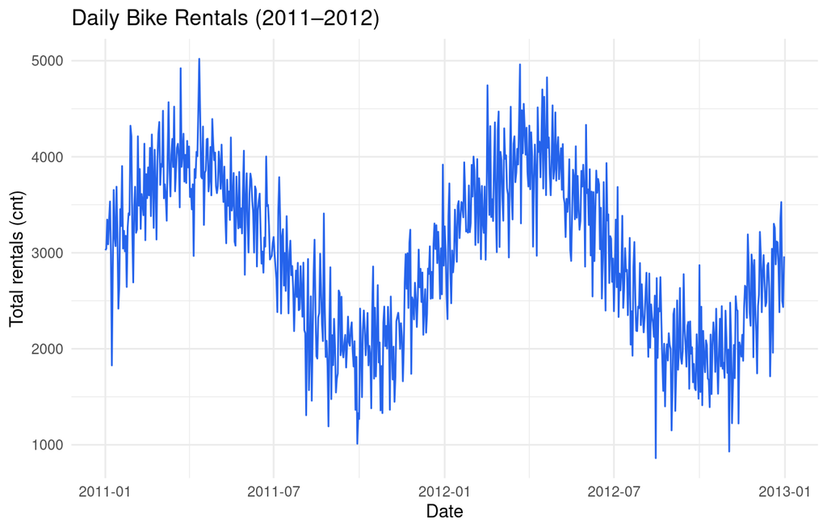

```r
ggplot(daily, aes(x = date, y = cnt)) +
  geom_line(color = "#2563EB") +
  labs(
    title = "Daily Bike Rentals (2011–2012)",
    x = "Date",
    y = "Total rentals (cnt)"
  ) +
  theme_minimal()
```

## 5.2 Monthly pattern

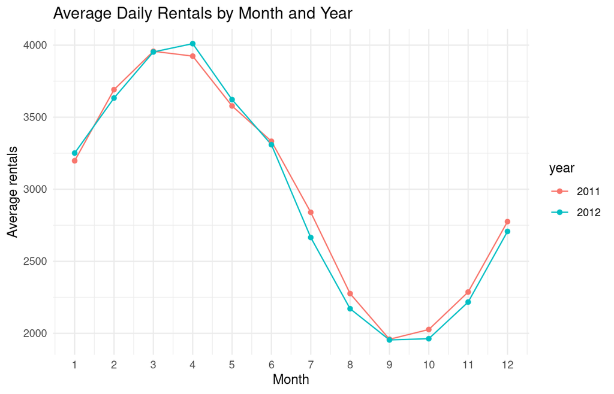

```r
daily %>%
  group_by(year, mnth) %>%
  summarise(avg_cnt = mean(cnt), .groups = "drop") %>%
  ggplot(aes(x = mnth, y = avg_cnt, group = year, color = year)) +
  geom_line() +
  geom_point() +
  scale_x_continuous(breaks = 1:12) +
  labs(
    title = "Average Daily Rentals by Month and Year",
    x = "Month",
    y = "Average rentals"
  ) +
  theme_minimal()
```

# 6 Time Series Object and Decomposition

We now create a daily time series for the whole period and decompose it into trend, seasonal, and remainder components.

```r
bike_ts <- ts(daily$cnt, frequency = 365)
bike_ts
```

```
## Time Series:
## Start = c(1, 1)
## End = c(3, 1)
## Frequency = 365
##   [1] 3027 3043 3346 3088 3340 3534 2989 1827 2827 3654 3174 3069 3688 3198 2418
##  [16] 2669 3455 3278 3903 3044 3229 3015 3177 2644 3262 3412 3393 4323 4212 3193
##  [31] 2691 3483 3688 3208 3242 4213 3491 3873 3249 3612 3514 3391 4136 3131 3819
##  [46] 3569 3889 3598 4093 3382 4232 3768 3259 4073 3731 3138 3964 4243 4362 3707
##  [61] 3925 3896 4479 3567 3713 3573 3334 4020 4568 3854 3587 4020 4186 3893 4522
##  [76] 3640 3855 4092 4135 4000 3473 4922 3895 4036 4240 3741 4020 3727 4165 3889
##  [91] 4107 3581 3667 3452 3713 2967 3872 3779 4051 4006 4488 5020 4434 3794 3774
## [106] 4315 3290 3832 3858 4182 4188 3639 3764 4102 3598 4393 4147 3964 4044 3693
## [121] 3621 3693 4054 3925 3666 4126 3746 3529 3897 3380 3099 3761 3489 3639 3342
## [136] 4201 3440 3520 3831 3117 3074 3794 3450 3254 3842 3263 3463 3201 3666 4063
## [151] 2771 3546 3828 3302 3003 3608 3825 3765 3539 3416 3002 3691 3653 2857 3442
```

[output cut: 38 more lines]

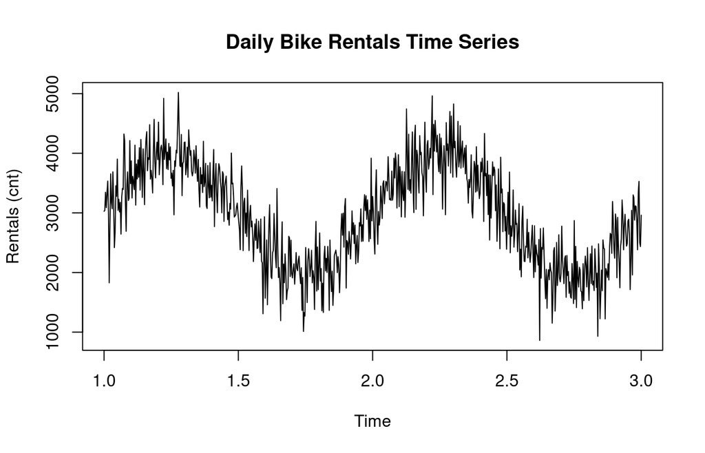

```r
plot(bike_ts,
     main = "Daily Bike Rentals Time Series",
     xlab = "Time",
     ylab = "Rentals (cnt)")
```

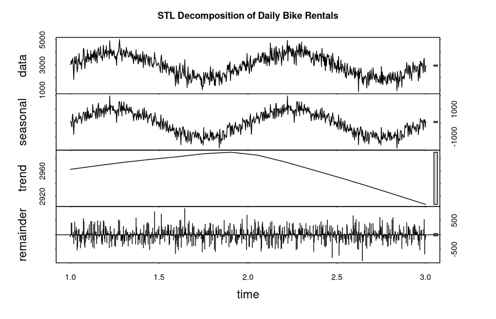

```r
bike_stl <- stl(bike_ts, s.window = "periodic")
plot(bike_stl, main = "STL Decomposition of Daily Bike Rentals")
```

# 7 Train / Test Split

We hold out the last 90 days as a test set to evaluate forecast accuracy.

```r
test_horizon <- 90
n <- length(bike_ts)

train_ts <- ts(bike_ts[1:(n - test_horizon)],
               frequency = frequency(bike_ts))
test_vec <- bike_ts[(n - test_horizon + 1):n]

length(train_ts); length(test_vec)
```

```
## [1] 641
```

```
## [1] 90
```

> Note: we keep the **training data** as a time series object, but treat the **test data** as a numeric vector. This avoids alignment issues when comparing forecasts to actuals.

# 8 Baseline Models

We first fit simple baseline models:

- **Naive**: the forecast is the last observed value
- **Seasonal naive**: the forecast repeats the last observed value from the same season

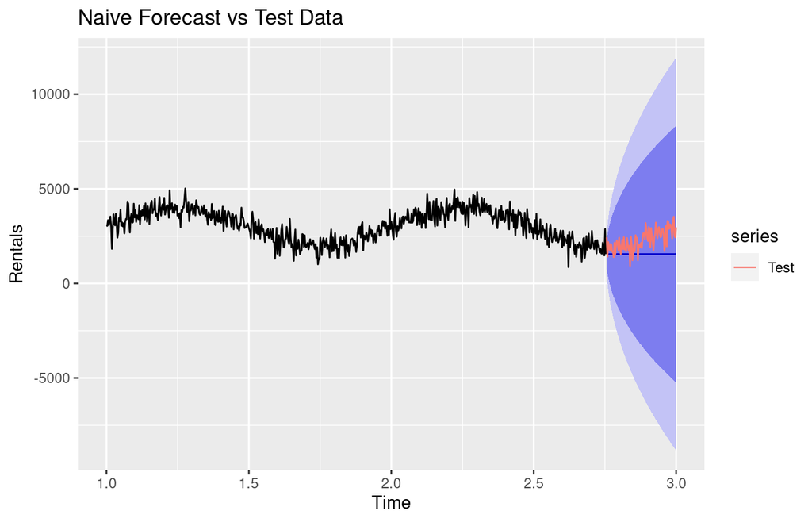

```r
naive_fit  <- naive(train_ts,  h = test_horizon)
snaive_fit <- snaive(train_ts, h = test_horizon)

autoplot(naive_fit) +
  autolayer(ts(test_vec, start = end(train_ts)[1] + end(train_ts)[2]/frequency(train_ts),
               frequency = frequency(train_ts)),
            series = "Test") +
  labs(
    title = "Naive Forecast vs Test Data",
    x = "Time",
    y = "Rentals"
  )
```

```r
naive_acc  <- accuracy(naive_fit$mean,  test_vec)
snaive_acc <- accuracy(snaive_fit$mean, test_vec)

baseline_results <- rbind(
  Naive          = naive_acc[ , c("RMSE", "MAE", "MAPE")],
  Seasonal_Naive = snaive_acc[ , c("RMSE", "MAE", "MAPE")]
)

baseline_results
```

```
##                    RMSE      MAE     MAPE
## Naive          922.9643 784.1778 31.37072
## Seasonal_Naive 502.9745 397.1333 19.02411
```

# 9 ARIMA Model

We now fit an ARIMA model on the training data using `auto.arima()`.

```r
arima_fit <- auto.arima(train_ts)
arima_fit
```

```
## Series: train_ts
## ARIMA(2,1,1)
##
## Coefficients:
##           ar1      ar2      ma1
##       -0.0628  -0.1216  -0.8142
## s.e.   0.0467   0.0447   0.0279
##
## sigma^2 = 174995:  log likelihood = -4770.5
## AIC=9549.01   AICc=9549.07   BIC=9566.85
```

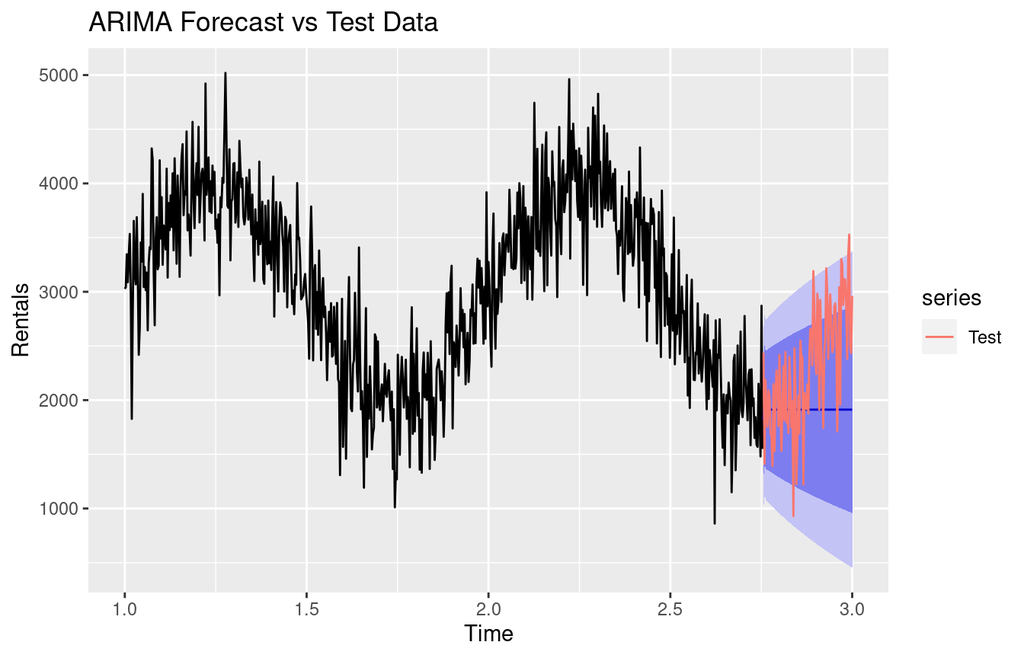

```r
fc_arima <- forecast(arima_fit, h = test_horizon)

autoplot(fc_arima) +
  autolayer(ts(test_vec, start = end(train_ts)[1] + end(train_ts)[2]/frequency(train_ts),
               frequency = frequency(train_ts)),
            series = "Test") +
  labs(
    title = "ARIMA Forecast vs Test Data",
    x = "Time",
    y = "Rentals"
  )
```

```r
arima_acc <- accuracy(fc_arima$mean, test_vec)
arima_acc[ , c("RMSE", "MAE", "MAPE")]
```

```
##      RMSE       MAE      MAPE
## 665.13779 532.17419  22.10166
```

# 10 ETS Model

We also fit an exponential smoothing (ETS) model for comparison.

```r
ets_fit <- ets(train_ts)
ets_fit
```

```
## ETS(A,A,N)
##
## Call:
##  ets(y = train_ts)
##
##   Smoothing parameters:
##     alpha = 0.0602
##     beta  = 0.0041
##
##   Initial states:
##     l = 3162.9441
##     b = 17.6781
##
##   sigma:  413.8734
##
##      AIC     AICc      BIC
## 11873.56 11873.65 11895.87
```

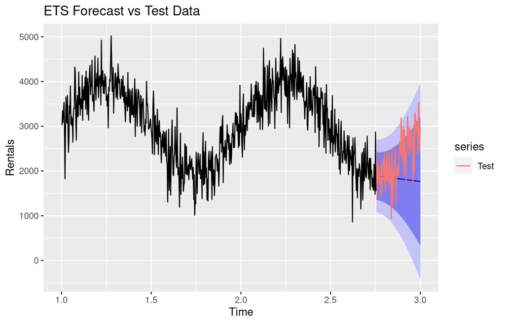

```r
fc_ets <- forecast(ets_fit, h = test_horizon)

autoplot(fc_ets) +
  autolayer(ts(test_vec, start = end(train_ts)[1] + end(train_ts)[2]/frequency(train_ts),
               frequency = frequency(train_ts)),
            series = "Test") +
  labs(
    title = "ETS Forecast vs Test Data",
    x = "Time",
    y = "Rentals"
  )
```

```r
ets_acc <- accuracy(fc_ets$mean, test_vec)
ets_acc[ , c("RMSE", "MAE", "MAPE")]
```

```
##      RMSE       MAE      MAPE
## 735.32565 589.00308  23.97915
```

# 11 Model Comparison

```r
model_comparison <- rbind(
  Naive          = naive_acc[ , c("RMSE", "MAE", "MAPE")],
  Seasonal_Naive = snaive_acc[ , c("RMSE", "MAE", "MAPE")],
  ARIMA          = arima_acc[ , c("RMSE", "MAE", "MAPE")],
  ETS            = ets_acc[ , c("RMSE", "MAE", "MAPE")]
)

model_comparison
```

```
##                    RMSE      MAE     MAPE
## Naive          922.9643 784.1778 31.37072
## Seasonal_Naive 502.9745 397.1333 19.02411
## ARIMA          665.1378 532.1742 22.10166
## ETS            735.3257 589.0031 23.97915
```

The model with the **lowest RMSE and MAPE** is generally preferred for forecasting.

# 12 Final Model and Future Forecast

```r
final_arima <- auto.arima(bike_ts)
final_arima
```

```
## Series: bike_ts
## ARIMA(0,0,0)(0,1,0)[365]
##
## sigma^2 = 268423:  log likelihood = -2806.88
## AIC=5615.77   AICc=5615.78   BIC=5619.67
```

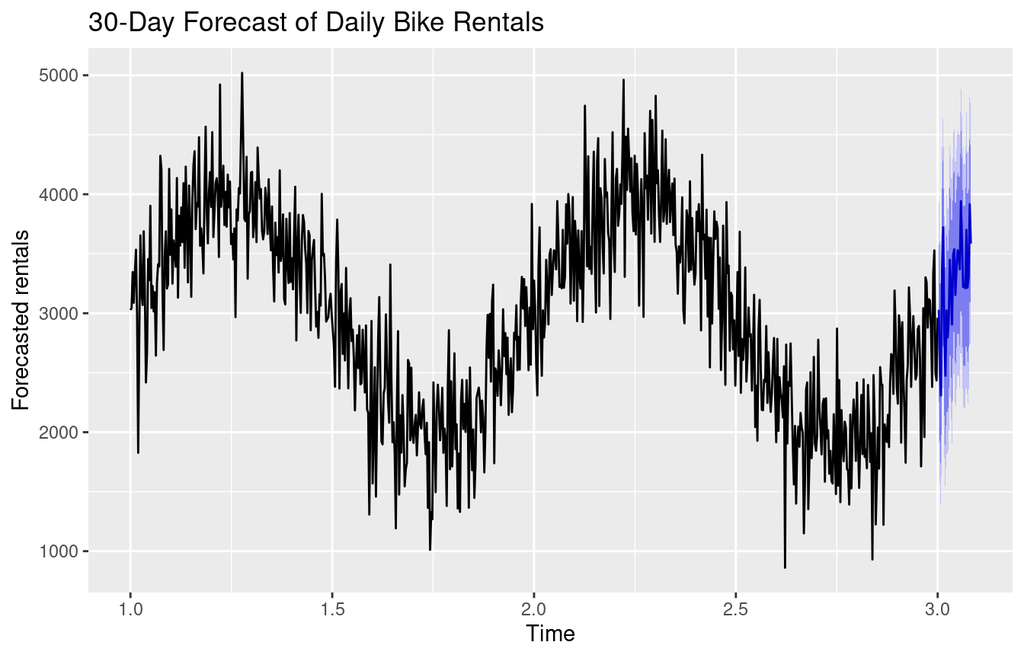

```r
final_fc <- forecast(final_arima, h = 30)

autoplot(final_fc) +
  labs(
    title = "30-Day Forecast of Daily Bike Rentals",
    x = "Time",
    y = "Forecasted rentals"
  )
```

```r
head(data.frame(
  Day = 1:30,
  Forecast = round(final_fc$mean)
), 10)
```

```
##    Day Forecast
## 1    1     3029
## 2    2     2558
## 3    3     2309
## 4    4     3385
## 5    5     3722
## 6    6     2826
## 7    7     2474
## 8    8     3024
## 9    9     2796
## 10  10     2928
```

# 13 Insights and Recommendations

From a business perspective, the company can:

- increase fleet size and staff coverage ahead of predicted high-demand periods,
- consider dynamic pricing, with higher prices on forecasted peak days,
- schedule maintenance and rebalancing during forecasted low-demand windows.

# 14 Conclusion